# MAC5768

## Lista de Exercícios - aulas 10 e 11

### Nota para o professor

Tomei a liberdade para remontar o pacote `ia636`, pois a versão disponível no AdessoWiki não compila. O código pode ser baixado em https://github.com/andersonfreitas/ia636

### Exercício 1

A imagem abaixo foi gerada com a função iacos da toolbox ia636. Leia a documentação da função e explique a imagem gerada pelo comando `iacos(s,t,theta,0)`

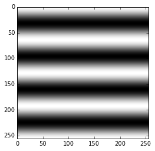

```python
from ia636 import *

s = (256,256)
t = 64
theta = pi/2
f = iacos(s, t, theta, 0)
imshow(f)
gray()
```

#### Resposta 1

O método `iacos()` cria uma imagem em tons de cinza com uma representação cosenoidal com amplitude $1$ na dimensão `s`, com o período `t`. A orientação da imagem é ajustada com o parâmetro $\theta$ e offset com o parâmetro $\phi$

Internamente a imagem é gerada através da equação abaixo para cada $x$ e $y$:

$$ I_{ x,y }=\cos ({ 2\pi [(\frac { 1 }{ t } \cos { \theta } )x+(\frac { 1 }{ t } \sin { \theta } )y]+\phi }) $$

### Exercício 2

Experimente mudar o ângulo theta e ver o que acontece. Tente pelo menos com cinco ângulos diferentes.

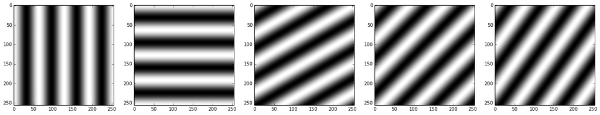

```python
figsize(22, 4)

angles = [pi, pi/2, pi/3, pi/4, pi/5]
imgs = []

for i, angle in enumerate(angles):
    subplot(1, 5, i+1)
    im = iacos(s, t, angle, 0)
    imgs.append(im)
    imshow(im)
```

### Exercício 3

Leia a documentação da função iadft e aplique-a nas cinco imagens que você gerou. Explique os resultados. Um exemplo:

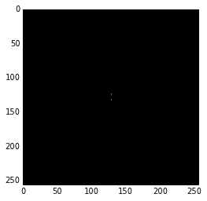

```python
F = iadft(f)
imshow(iadftview(F));
```

#### Resposta

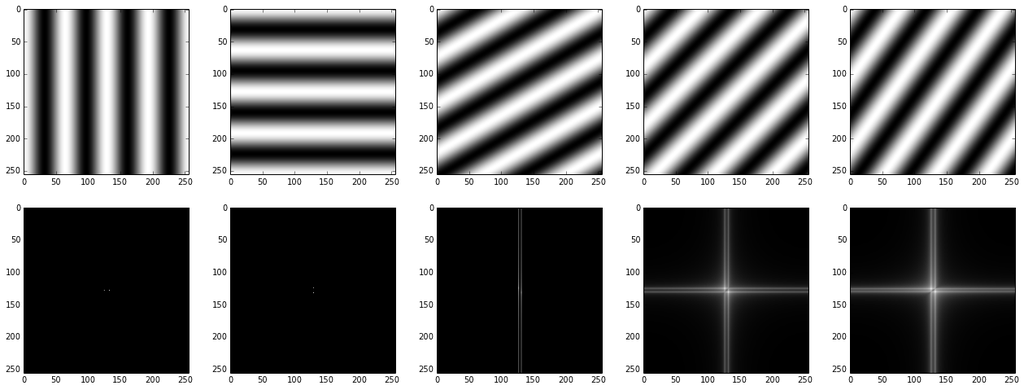

```python
figsize(22, 8)

for i, im in enumerate(imgs):
    subplot(2, 5, i+1)
    imshow(im)

    subplot(2, 5, 6+i)
    imshow(iadftview(iadft(im)))
```

### Exercício 4

Leia o exemplo `iacosdemo` da toolbox ia636 que explica um problema da DFT. Repita o exemplo `iacosdemo` aumentando (fazendo um preenchimento com zeros) a imagem para 256x256 pontos (ao invés de 128x256 pontos). O que você observa?

### Exercício 5

Escolha 3 imagens do banco de imagens da disciplina e exercite os filtros passa-baixa, passa-alta e passa-banda em todas elas (escolha imagens e frequências que façam algum sentido).